# Week 03 - Assignment

Ann-Sophie Frind

2024-03-10

# Preparations

```r
suppressPackageStartupMessages({
  library(AnnotationHub) # retrieve genomes and annotations
  library(Rsubread) # handles alignment
  library(rtracklayer) # import, export files
  library(Biostrings) # handle seqences
  library(Rfastp) # read trimming & qc
  library(epiwraps) # visualization
})
ah <- AnnotationHub()
# if on renku, use ah <- AnnotationHub(cache="ahcache")
```

# Background (for myself)

Chip-seq (ChIP-sequencing) is a powerful experimental technique used in molecular biology to study protein-DNA interactions. The term “ChIP” stands for Chromatin Immunoprecipitation. Immunoprecipitation (IP) is a laboratory technique used to isolate a specific protein or complex of proteins from a complex mixture of proteins. It relies on the use of antibodies to selectively bind to the protein of interest, followed by precipitation of the antibody-protein complex, which can then be isolated and analyzed.

ChIP-seq combines chromatin immunoprecipitation (ChIP) with high-throughput sequencing to identify regions of the genome that are bound by specific proteins, such as transcription factors or histone modifications.

Here’s an overview of the process:

ChIP (Chromatin Immunoprecipitation): In this step, cells are fixed and their chromatin (DNA and associated proteins) is cross-linked. Then, a specific antibody is used to immunoprecipitate the protein of interest along with the DNA fragments it is bound to. This results in a mixture of DNA fragments that are bound by the protein and DNA fragments that are not bound. Sequencing Library Preparation: The immunoprecipitated DNA fragments are purified and converted into a sequencing library. This involves processes such as end repair, A-tailing, adapter ligation, and PCR amplification.

Sequencing: The sequencing library is then sequenced using high-throughput sequencing technologies, such as Illumina sequencing. This generates millions of short DNA sequence reads.

Data Analysis: The sequence reads are aligned to a reference genome using bioinformatics tools and software. This allows researchers to determine the genomic locations of the DNA fragments that were bound by the protein of interest.

Peak Calling: After alignment, bioinformatics tools are used to identify regions of the genome that show significant enrichment of sequence reads compared to background levels. These regions are referred to as “peaks” and represent the genomic regions where the protein of interest is bound.

Functional Analysis: Once peaks have been identified, researchers can perform downstream analyses to gain insights into the biological function of the protein-DNA interactions. This may involve annotating peaks with nearby genes, identifying enriched transcription factor binding motifs, or studying the relationship between protein binding and gene expression. ChIP-seq data can provide valuable insights into various biological processes, including gene regulation, chromatin structure, and epigenetic modifications. It is widely used in fields such as genetics, genomics, developmental biology, and cancer research to study the interactions between proteins and DNA at a genome-wide scale.

# 1 Download

Download the following Drosophila ChIP-seq for the protein CTCF: https://www.encodeproject.org/files/ENCFF127RRR/@@download/ENCFF127RRR.fastq.gz (no input control for the purpose of this exercise) Note for myself: it is recommended to download it via programming.

```r
# increasing download timeout
options(timeout=3600)

# creating a directory (=folder) on my laptop
dir.create("raw")

# downloading and storing in previously created folder
download.file("https://www.encodeproject.org/files/ENCFF127RRR/@@download/ENCFF127RRR.fastq.gz", dest="raw/Myc.fastq.gz", mode = "wb")
download.file("https://www.encodeproject.org/files/ENCFF127RRR/@@download/ENCFF127RRR.fastq.gz", dest="raw/input.fastq.gz", mode="wb") # dest = destination, where to save
```

# 2 Process it from the raw data, obtaining:

## 2.1 .bam file

To obtain .bam files, the raw reads in .fastq.gz format (which we downloaded in the step before) need to be first quality controles (QC) and trimmed. Then they are aligned with a reference genome. We save the compressed .sam –> .bam files.

```r
# QC and Trimming using R and Rfastp

## Creating a new directory/folder
dir.create("rfastp.trimmed")
```

```r
## Creating a list to save the loop
fastq_files <- c(Myc="raw/Myc.fastq.gz", input="raw/input.fastq.gz")

## Using the "apply" function family to apply a function on the values on our list
qc <- lapply(c(Myc="raw/Myc.fastq.gz", input="raw/input.fastq.gz"), # specifies the input
             FUN=function(x){ # specifies what function is applied to the input
  Rfastp::rfastp(x, thread=4, overrepresentationAnalysis=TRUE,
                 outputFastq=file.path("rfastp.trimmed/",gsub("\\.fastq\\.gz$","",basename(x))))
})

## Show the generated QC plots in R
# Rfastp::curvePlot(qc$Myc, curve="content_curves")
```

```r
# Alignment

## Building a genome index for mapping (only needs to be done once for a genome)
## --> The index represents the reference genome and allows for fast searching and alignment of short reads.

### we get the reference genome sequence of drosophila melanogaster from AnnotationHub "fetch"
genome <- ah[["AH49674"]]

### we create a new directory that will contain the reference genome index
dir.create("BDGP6_genome")

### we write the genome sequence in fasta format
export(import.2bit(genome), "BDGP6_genome/genome.fasta.gz", compress=TRUE)

### we build a Rsubread index
Rsubread::buildindex("BDGP6_genome/rsubread", reference="BDGP6_genome/genome.fasta.gz")
```

```r
## Again creating a folder to save the stuff in
dir.create("aligned")
## Align with reference genome sequence
align.stats <- Rsubread::align(index="BDGP6_genome/rsubread", type="dna",
                               readfile1=c("rfastp.trimmed/Myc_R1.fastq.gz",
                                           "rfastp.trimmed/input_R1.fastq.gz"),
                               output_file=c("aligned/Myc.bam","aligned/input.bam"),
                               nthreads=6, sortReadsByCoordinates=TRUE) # threads depend on your computer --> threads - 1
```

[output not shown]

[output cut: 108 more lines]

```
##
## //================================   Summary =================================\\
## ||                                                                            ||
## ||                 Total reads : 3,816,990                                    ||
## ||                      Mapped : 3,504,769 (91.8%)                            ||
## ||             Uniquely mapped : 3,048,315                                    ||
## ||               Multi-mapping : 456,454                                      ||
## ||                                                                            ||
## ||                    Unmapped : 312,221                                      ||
## ||                                                                            ||
## ||                      Indels : 1,836                                        ||
## ||                                                                            ||
## ||                Running time : 4.5 minutes                                  ||
## ||                                                                            ||
## \\============================================================================//
```

```r
# find out how many threads my computer has
parallel::detectCores() # I have 8
```

```
## [1] 8
```

```r
## print
align.stats
```

```
##                       Myc.bam input.bam
## Total_reads           3816990   3816990
## Mapped_reads          3504769   3504769
## Uniquely_mapped_reads 3048315   3048315
## Multi_mapping_reads    456454    456454
## Unmapped_reads         312221    312221
## Indels                   1836      1836
```

## 2.2 Peaks

For that MACS3 was recommended, which has to be installed first (e.g. via pip). That didn’t work so I used the R alternative.

```r
peaks <- callPeaks("aligned/Myc.bam", fragLength=50L)
```

```
## Reading signal and identifying candidate regions...
```

```
## Reading signal coverage...
```

```
## 43925 initial candidate regions
```

```
## Getting strand information
```

```
## 11079 peaks after filtering
```

```
## Reading signal coverage...
```

```
## 23993 initial candidate regions
```

```
## Getting strand information
```

```
## 5739 peaks after filtering
```

```
## Reading signal coverage...
```

```
## 23556 initial candidate regions
```

```
## Getting strand information
```

```
## 5909 peaks after filtering
```

```
## Reading signal coverage...
```

```
## 15568 initial candidate regions
```

```
## Getting strand information
```

```
## 4009 peaks after filtering
```

```
## Identified 26736 candidate regions
```

```
## Computing significance...
```

```
## (In the absence of a control, FDR is unlikely to be calibrated)
```

```
## Reporting 2857 regions, 1619 with FDR<0.05
```

```r
# if we want to save it as a bed file:
rtracklayer::export.bed(peaks, "peaks/peaks.bed")
```

# 3 Report:

## 3.1 How many reads (and what percentage) were mapped

```r
head(peaks)
```

```
## GRanges object with 6 ranges and 9 metadata columns:
##       seqnames      ranges strand |  maxCount meanCount    maxPos    maxNeg
##          <Rle>   <IRanges>  <Rle> | <integer> <numeric> <integer> <integer>
##   [1]       2L   1647-1674      * |        14   14.0000         9         5
##   [2]       2L   1799-1824      * |        15   15.0000         8         7
##   [3]       2L   3148-3174      * |        25   25.0000        11        14
##   [4]       2L   3599-3625      * |        27   27.0000        12        15
##   [5]       2L   4048-4075      * |        21   21.0000        13         8
##   [6]       2L 21363-21498      * |        22   14.0368         9        14
##              bg   log10FE    log10p  log10FDR     score
##       <numeric> <integer> <numeric> <numeric> <integer>
##   [1]   1.64775        75      3.23      0.00       493
##   [2]   1.68360        78      4.99      0.59       513
##   [3]   1.56642       101      9.08      4.67       664
##   [4]   1.53083       104     10.20      5.78       684
##   [5]   1.54288        94      5.95      1.55       618
##   [6]   1.84480        72      6.95      2.55       474
##   -------
##   seqinfo: 1870 sequences from an unspecified genome; no seqlengths
```

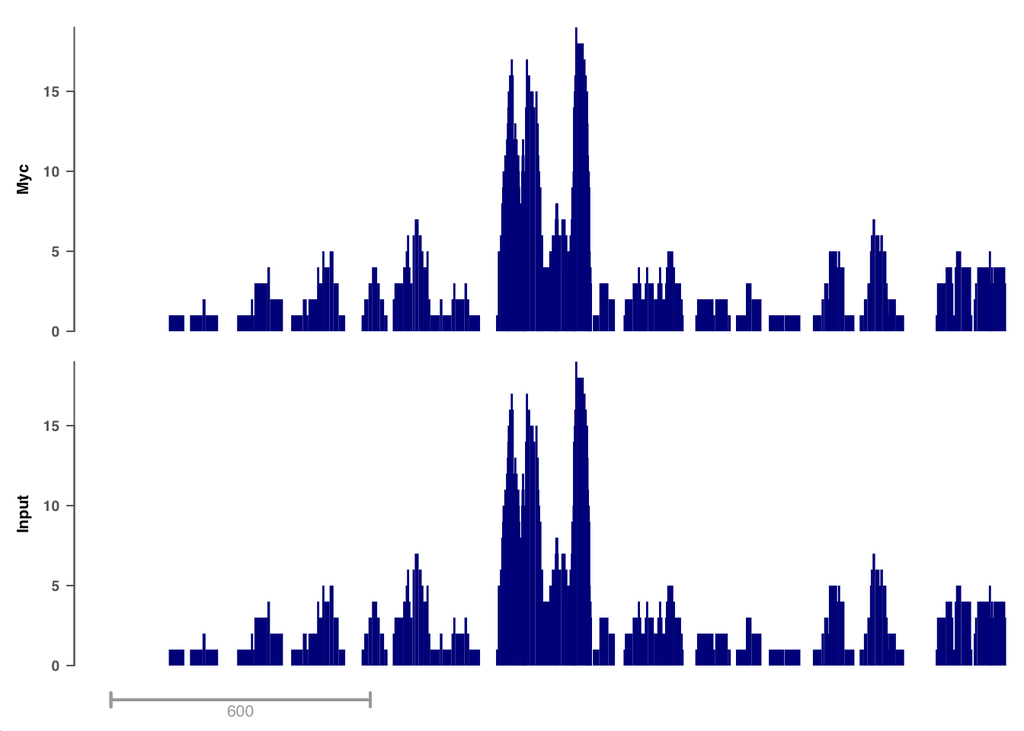

```r
plotSignalTracks(c(Myc="aligned/Myc.bam", Input="aligned/input.bam"),
                 region=peaks[6],
                 extend=1000)
```